# Curso de análisis de datos para el manejo de las Sequías

Cristian J. Diaz Moscote, cdiaz@uniguajira.edu.co  
Rosa A. Rodriguez Fernandez, rangelicarodriguez@uniguajira.edu.co

23 October, 2024

# **Objetivos del curso**

### **Objetivo General**

- Desarrollar competencias necesarias para realizar análisis de datos utilizando RStudio para el monitoreo de sequías, aplicando técnicas modernas y buenas prácticas en el manejo de datos.

### **Objetivos Específicos**

- Introducir a los participantes al entorno de RStudio y al lenguaje de programación R
- Proporcionar a los estudiantes las habilidades necesarias para importar, limpiar y transformar datos
- Facilitar la comprensión y aplicación de índices de sequías, así como la creación mapas

# **Justificación del curso**

- La programación es una herramienta fundamental para todo profesional (Rahman, 2023), la habilidad de programar permite a las personas abrirse al mundo (Goldiamond, 2022).
- Los lenguajes de programación “open acces” permiten un mejor desarrollo de competencias y habilidades en los estudiantes (Silva et al., 2020).
- El análisis de datos para el manejo efectivo de las sequías es uno de los desafíos más críticos a nivel global (Díaz Mercado, 2022), especialmente en regiones vulnerables donde los efectos del cambio climático agravan la escasez de agua.
- Las sequías no solo afectan la disponibilidad de recursos hídricos, sino que también repercuten negativamente en la agricultura, la biodiversidad y el bienestar de las comunidades (Vicente-Serrano et al., 2010).
- Para enfrentar estos desafíos, es necesario contar con herramientas avanzadas que permitan monitorear, analizar y predecir eventos de sequía de manera precisa y eficiente (West et al., 2019).

# **Contenido del curso**

### **Módulo 1: Introducción a R y RStudio**

1.1. Presentación del entorno R y RStudio

1.2. Manipulación de datos en R

### **Módulo 2: Fundamentos de la sequía**

2.1. Conceptos básicos de la sequía

2.2. Índices de sequía: conceptos y fundamentos

### **Módulo 3: Monitoreo de la sequía**

3.1. Fuentes de datos hidrometeorológicos

3.2. Estimación del Índice Estandarizado de Precipitación

3.2. Cálculo de la duración, severidad e intensidad de la sequía

### **Módulo 4: Visualización de datos de sequía**

4.1. Gráficos básicos en R

4.2. Mapas y visualización espacial de la sequía

# Aprendizaje esperado

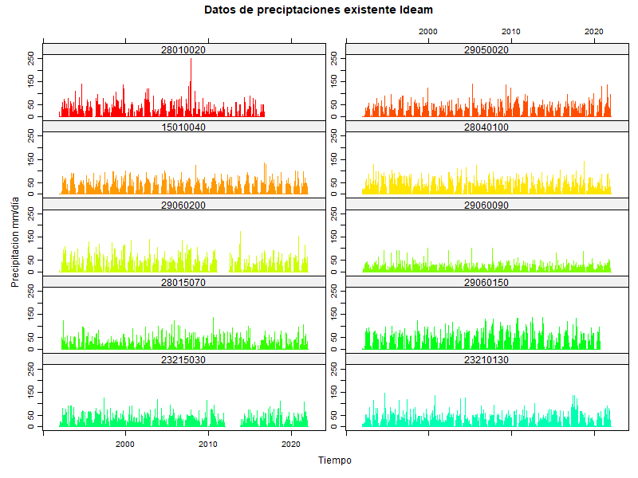

# Aprendizaje esperado

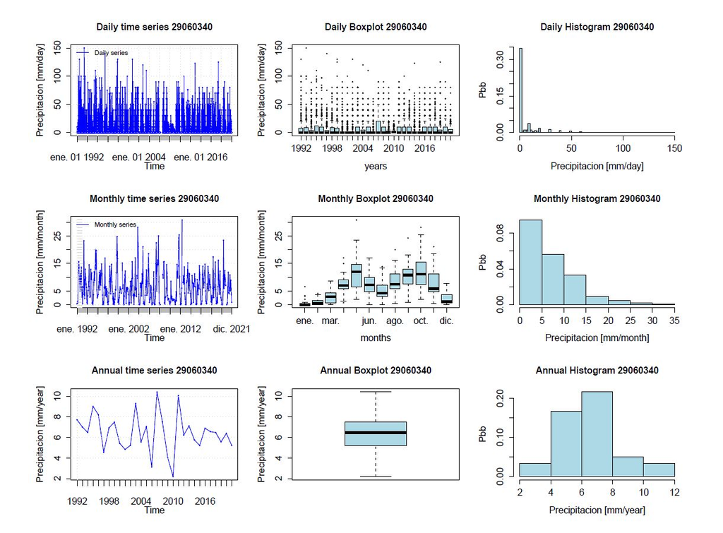

# Aprendizaje esperado

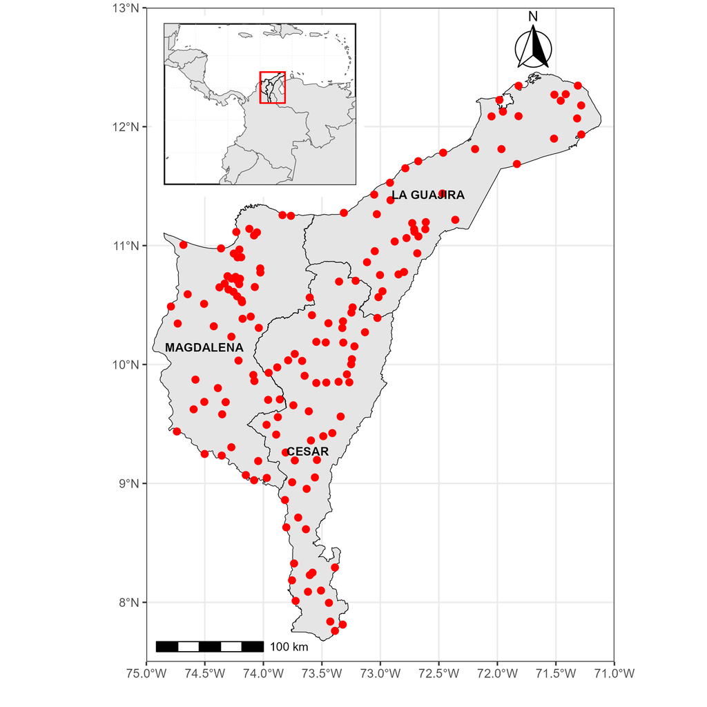

# Aprendizaje esperado

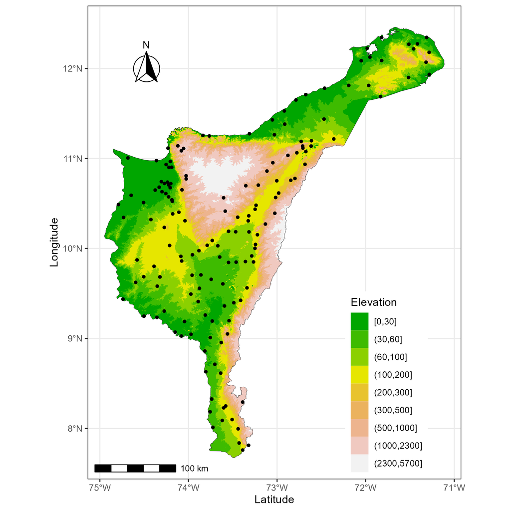

# Aprendizaje esperado

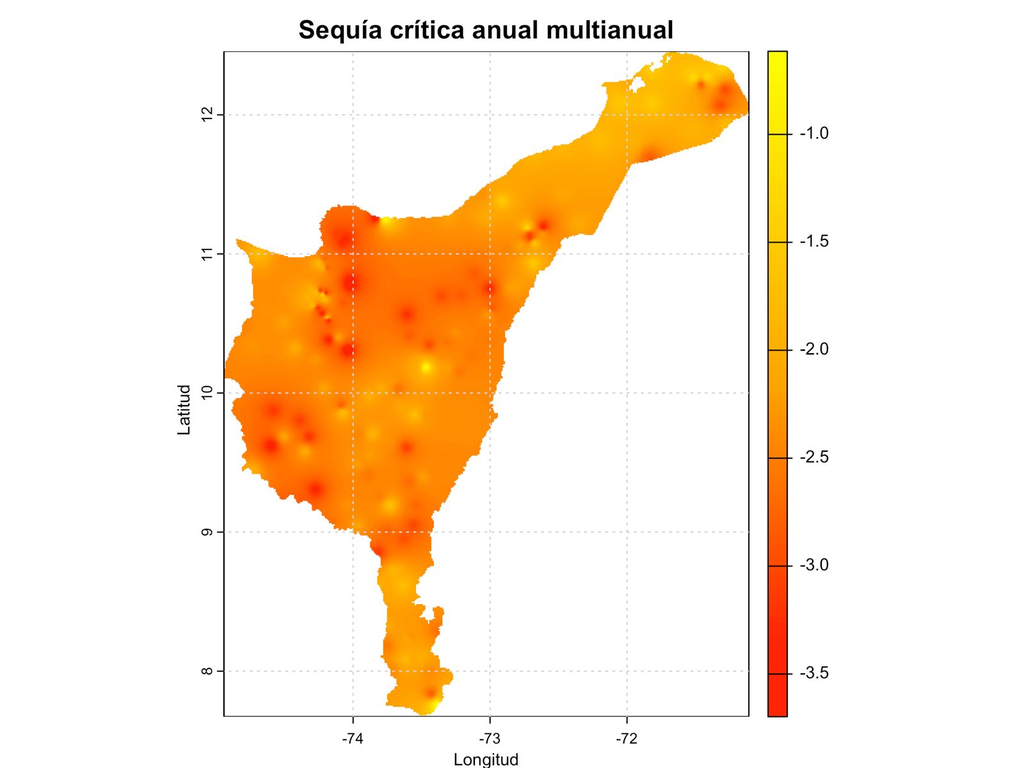

# Aprendizaje esperado

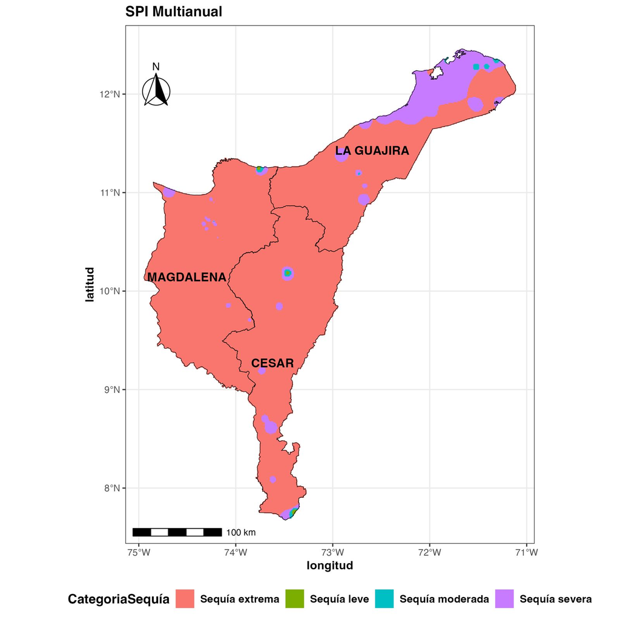

# Aprendizaje esperado

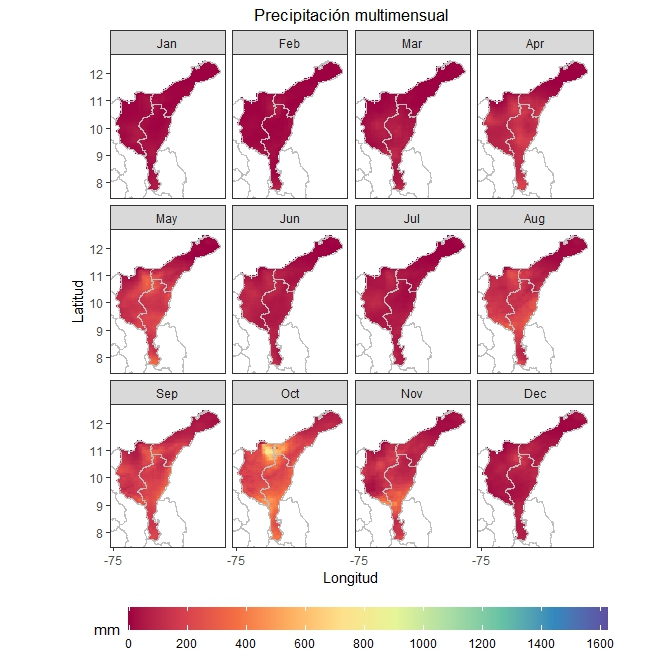

# Aprendizaje esperado

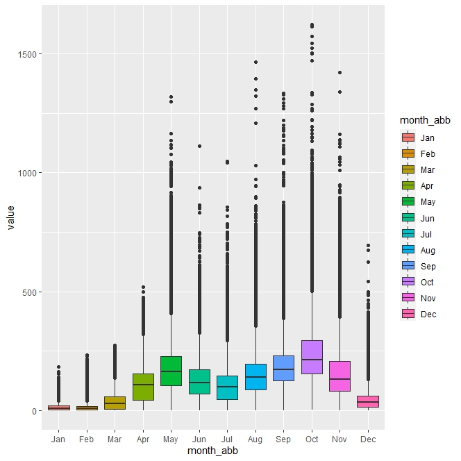

# Hablemos de R y Rstudio

[figure not shown]

- R es un lenguaje de **programación** y es un software libre
- RStudio es la interfaz de usuario más conocida (hace que R sea amigable e incluye herramientas para facilitar el trabajo)
- R es un lenguaje orientado a **objetos** en donde pueden aplicarse **funciones** a estos objetos.

# Por qué usar R

- Es un software libre y gratuito
- Permite hacer investigación reproducible:
  - El flujo de trabajo queda escrito en código
  - Los análisis se hacen dentro del mismo programa
- Es una herramienta potente y está en constante desarrollo de nuevas funcionalidades.
- Existe una gran comunidad alrededor del mundo que siempre está dispuesta a enseñar, responder preguntas y desarrollar nuevos paquetes.
- Aprender a **buscar en Google** es primordial

# R Base v/s tidyverse

### R Base

[figure not shown]

- Programar con la sintaxis nativa de R
- Índices de objetos se realizan con: `$ , [ ], [,] o [[]]`
- Funciones incluidas en el paquete base (base::)

### R Tidyverse

[figure not shown]

- Grupo de paquetes diseñados para hacer ciencia de datos
- Busca una programación más intuitiva. Funciones como verbos.
- Todos los paquetes comparten una filosofía de diseño, gramática y estructuras de datos subyacentes.
- Operador “pipe” %>%

# Libros

[figure not shown]

Geocomputation with R

# Recomendaciones

- El conocimiento no está en un solo lugar.
- Usa la ayuda siempre será tu amiga.
- Busca en Google seguro alguien tuvo el mismo problema que tú y ya fue resuelto.
- La información más relevante siempre la encontraras en inglés.
- No existe un solo método para hacer las cosas.

# **Referencias**

Díaz Mercado, V. (2022). *Visual approaches to drought analysis* (pp. 67–78). CRC Press. https://doi.org/10.1201/9781003279655-8

Goldiamond, I. (2022). *A Programing Contingency Analysis of Mental Health*. https://doi.org/10.4324/9781003260103

Rahman, M. T. (2023). Blended approach for deep learning: A framework for teaching undergraduate computer programming courses. *Proceedings of the 15th International Conference on Computer Supported Education*, 394–402. https://doi.org/10.5220/0011959900003470

Silva, J., Wiese, I., German, D. M., Treude, C., Gerosa, M. A., & Steinmacher, I. (2020). A theory of the engagement in open source projects via summer of code programs. *Proceedings of the 28th ACM Joint Meeting on European Software Engineering Conference and Symposium on the Foundations of Software Engineering*, *50*, 421–431. https://doi.org/10.1145/3368089.3409724

Vicente-Serrano, S. M., Beguería, S., & López-Moreno, J. I. (2010). A Multiscalar Drought Index Sensitive to Global Warming: The Standardized Precipitation Evapotranspiration Index. *Journal of Climate*, *23*(7), 1696–1718. https://doi.org/10.1175/2009jcli2909.1

West, H., Quinn, N., & Horswell, M. (2019). Remote sensing for drought monitoring & impact assessment: Progress, past challenges and future opportunities. *Remote Sensing of Environment*, *232*, 111291. https://doi.org/10.1016/j.rse.2019.111291